# Exercise 2: Logistic Regression

```python
import pandas
import numpy as np
import scipy.optimize
import matplotlib.pyplot as plt
import math
%matplotlib inline
```

## Part 1: Plotting

We start the exercise by first plotting the data to understand the the problem we are working with.

```python
data1 = pandas.read_csv("ex2data1.txt", header=None, names=['test1', 'test2', 'accepted'])
data1.head()
```

|  | test1 | test2 | accepted |
| --- | --- | --- | --- |
| 0 | 34.623660 | 78.024693 | 0 |
| 1 | 30.286711 | 43.894998 | 0 |
| 2 | 35.847409 | 72.902198 | 0 |
| 3 | 60.182599 | 86.308552 | 1 |
| 4 | 79.032736 | 75.344376 | 1 |

Plotting data with + indicating (y = 1) examples and o indicating (y = 0) examples.

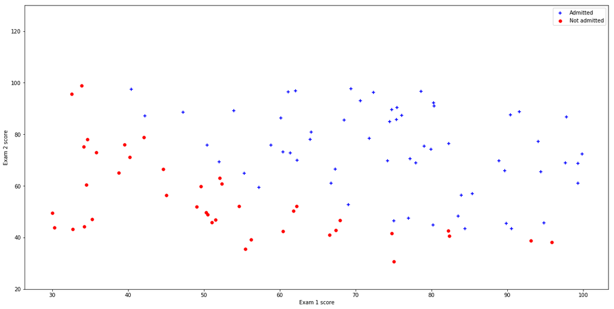

```python
def plotData(data):
    fig, ax = plt.subplots(figsize=(20,10))
    results_accepted = data[data.accepted == 1]
    results_rejected = data[data.accepted == 0]
    ax.scatter(results_accepted.test1, results_accepted.test2, marker='+', c='b', s=40)
    ax.scatter(results_rejected.test1, results_rejected.test2, marker='o', c='r', s=30)
    return ax

ax = plotData(data1)
ax.set_ylim([20, 130])
ax.legend(['Admitted', 'Not admitted'], loc='best')
ax.set_xlabel('Exam 1 score')
ax.set_ylabel('Exam 2 score')
```

```python
X = data1[['test1', 'test2']].values
y = data1.accepted.values
m, n = X.shape
X = np.insert(X, 0, np.ones(len(X)), 1)
m, n
print (y.shape)
```

```
(100,)
```

## Part 2: Compute Cost and Gradient

In this part of the exercise, you will implement the cost and gradient for logistic regression. You neeed to complete the code in the function `cost`.  
Before you start with the actual cost function, recall that the logistic regression hypothesis is defined as:

$h_\theta(x)=g(\theta^Tx)$

where function g is the sigmoid function. The sigmoid function is defined as:

$g(z)=\frac{1}{1+e^{-z}}$

```python
def sigmoid(z):
    #SIGMOID Compute sigmoid functoon
    #   J = SIGMOID(z) computes the sigmoid of z.

    # You need to return the following variables correctly
    g = np.zeros(z.shape)

    # ====================== YOUR CODE HERE ======================
    # Instructions: Compute the sigmoid of each value of z (z can be a matrix,
    #               vector or scalar).


    g = np.divide(1, 1 + np.exp(-z))



    # =============================================================

    return g
```

Now you will implement the cost function and gradient for logistic regression. Complete the code in costFunction.m to return the cost and gradient.  
Recall that the cost function in logistic regression is

$J(\theta)=\frac{1}{m}\sum\limits_{i=1}^m \:[-y^{(i)}\log(h_\theta(x^{(i)}))-(1-y^{(i)})\log(1-h_\theta(x^{(i)}))]$

and the gradient of the cost is a vector of the same length as θ where the jth element (for j = 0,1,...,n) is defined as follows:

$\frac{\partial J(\theta)}{\partial \theta_j} = \frac{1}{m}\sum\limits_{i=1}^m \:({h}_\theta({x}^{(i)})-{y}^{(i)})x_j^{(i)}$

Note that while this gradient looks identical to the linear regression gra- dient, the formula is actually different because linear and logistic regression have different definitions of hθ(x).

```python
def cost(X, y, th, _lambda=0):
    #COSTFUNCTION Compute cost and gradient for logistic regression
    #   J = COSTFUNCTION(theta, X, y) computes the cost of using theta as the
    #   parameter for logistic regression and the gradient of the cost
    #   w.r.t. to the parameters.

    # Initialize some useful values
    m = len(y)

    # You need to return the following variables correctly
    J = 0


    # ====================== YOUR CODE HERE ======================
    # Instructions: Compute the cost of a particular choice of theta.
    #               You should set J to the cost.
    #               Compute the partial derivatives and set grad to the partial
    #               derivatives of the cost w.r.t. each parameter in theta
    #
    hyp = sigmoid(np.dot(X,th))

    J = np.sum(np.dot(-y.T, np.log(hyp)) - np.dot((1 - y).T, np.log(1 - hyp)))
    J /= m


    # =============================================================

    return J
```

```python
def gradient(X, y, th, _lambda=0):
    # Initialize some useful values
    m = len(y)

    # You need to return the following variables correctly
    grad = np.zeros(th.shape)

    # ====================== YOUR CODE HERE ======================
    hyp = sigmoid(np.dot(X, th))
    grad = (np.dot(X.T, hyp - y))
    grad /= m




    # =============================================================

    return grad
```

```python
initial_theta = np.zeros(n + 1)
initial_theta.shape
```

```
(3,)
```

The cost at initial theta (zeros) should be about `0.693`.

```python
cost(X, y, np.array(initial_theta))
```

```
0.69314718055994518
```

The gradient at initial theta should be `[-0.1, -12.01, -11.26]`.

```python
gradient(X, y, np.array([0,0,0]))
```

```
array([ -0.1       , -12.00921659, -11.26284221])
```

## Part 3: Optimizing using fminunc

In this exercise, you will use a built-in function (scipy.optimize.fmin_ncg) to find the optimal parameters theta.

```python
def mycost(t):
    return cost(X, y, t)

def mygrad(t):
    return gradient(X, y, t)

import timeit
start = timeit.default_timer()


optimal_theta = scipy.optimize.fmin_ncg(mycost,
                                        initial_theta,
                                        fprime=mygrad)


stop = timeit.default_timer()
print(stop - start)
```

```
Optimization terminated successfully.
         Current function value: 0.203498
         Iterations: 28
         Function evaluations: 71
         Gradient evaluations: 246
         Hessian evaluations: 0
0.009634535992518067
```

Value of theta that minimizes the cost function:

```python
optimal_theta
```

```
array([-25.15286245,   0.20616395,   0.20140306])
```

```python
print (np.max(X[:, 2]))
```

```
98.8694357422
```

We plot the decision boundary.

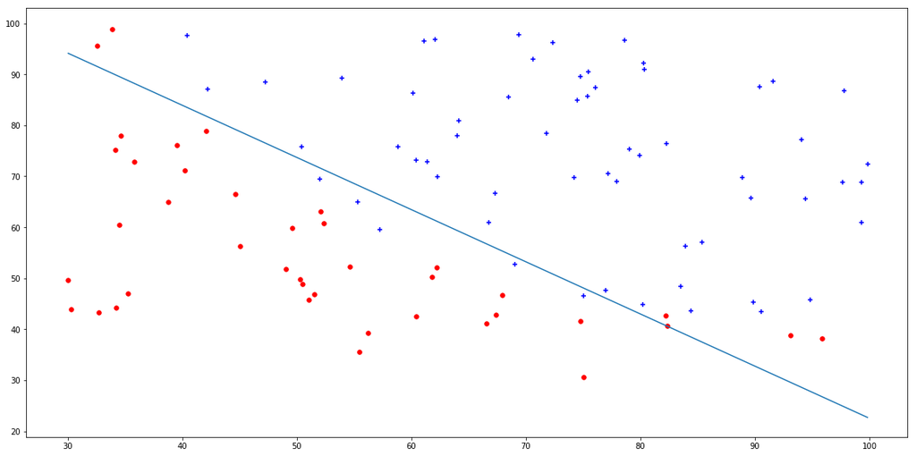

```python
ax = plotData(data1)
x_plot = np.array([np.max(X[:, 1]), np.min(X[:,1])])
y_plot = (-optimal_theta[0] - optimal_theta[1]*x_plot) / (optimal_theta[2])
ax.plot(x_plot, y_plot)
```

## Part 4: Predict and Accuracies

Your task is to complete the code in `predict`.

```python
def predict(t, x):
    #PREDICT Predict whether the label is 0 or 1 using learned logistic
    #regression parameters theta
    #   p = PREDICT(theta, X) computes the predictions for X using a
    #   threshold at 0.5 (i.e., if sigmoid(theta'*x) >= 0.5, predict 1)

    m = X.shape[0] # Number of training examples

    # You need to return the following variables correctly
    p = np.zeros(m)

    # ====================== YOUR CODE HERE ======================
    # Instructions: Complete the following code to make predictions using
    #               your learned logistic regression parameters.
    #               You should set p to a vector of 0's and 1's
    #


    threshold = 0.5
    sig = sigmoid(np.dot(x, t))
    for i in range(m):
        if sig[i] >= threshold:
            p[i] = 1
        else:
            p[i] = 0

    # =========================================================================

    return p
```

Training set accuracy:

```python
print ('logistic regression, training accuracy : ' + str(np.mean(predict(optimal_theta, X) == y)))
```

```
logistic regression, training accuracy : 0.89
```

# K-Nearest Neighbors

KNN is a form of *instance*, or *memory* based learning wherein we don't learn a function $f(X)$ to estimate $E[Y|X]$. Rather, to make a classification for a given instance $X_i$, we search the training data for the $k$ nearest neighbors, as defined by some distance metric $d(X_i,X_j)$. The estimate of $E[Y|X]$ is then given by:

$E[Y|X] = \sum\limits_{y_i \in N(X)}^k Y_i$

The most common distance function used in kNN is the *Euclidean Distance*.  
Let $X = $ be a $p$-dimensional vector, then for two instances $i$ and $j$:

$eud(X_i,X_j) = \sqrt{(x_i^1-x_j^1)^2+...+(x_i^p-x_j^p)^2} = \sqrt{\sum\limits_{t=1}^p (x_i^t-x_j^t)^2}$

See here for implementation details, (https://en.wikipedia.org/wiki/K-nearest_neighbors_algorithm)

```python
import operator
def euclideanDistance(targetX, dataSet):

    m = len(dataSet[0])
    distances = np.zeros(m)

    # ====================== YOUR CODE HERE ======================
    # Instructions: Complete the code to obtain euclideanDistance between one targetX and the other.
    #

    distances = np.sqrt(np.sum(np.power(targetX - dataSet, 2), axis=1))


    # =========================================================================

    return distances


def getKNN(targetX, dataSet, labels, k):
    ## targetX : target data
    ## dataset : other data
    ## labels
    ## k : number of neighbors

    # compute euclidean distance
    distances = euclideanDistance(targetX,dataSet)
    closest_data = 0

    # ====================== YOUR CODE HERE ======================
    # Instructions: Use the result of finding the distance between TargetX and other data,
    #               select the most out of k data closest to target data
    #

    indices = np.argsort(distances)
    k_values =  labels[indices[:k]]

    #k_values = np.argpartition(targetX, k)
    ones = (k_values == 1).sum()
    zeros = (k_values == 0).sum()
    if ones > zeros:
        closest_data = 1
    else:
        closest_data = 0

    # =========================================================================

    return closest_data

def predictKNN(X, y, k):
    predicted_array = np.zeros((X.shape[0],))

    for i in range(X.shape[0]):
        predicted_array[i] = getKNN(X[i],X,y,k)

    return predicted_array
```

```python
#x = (X - X[0])
```

```python
k=2
result_knn = predictKNN(X,y,k)
```

[figure not shown]

```python
def plotData(data):
    fig, ax = plt.subplots(figsize=(20,10))
    results_accepted = data[data.accepted == 1]
    results_rejected = data[data.accepted == 0]
    ax.scatter(results_accepted.test1, results_accepted.test2, marker='+', c='b', s=40)
    ax.scatter(results_rejected.test1, results_rejected.test2, marker='o', c='r', s=30)
    return ax
ax = plotData(data1)
ax.set_ylim([20, 130])
i = 0
for xy in zip(X[:,1],X[:,2]):
    ax.annotate('(%s)' % int(result_knn[i]), xy=xy, textcoords='data',size=15)
    i += 1
ax.set_ylim([20, 130])
ax.legend(['Admitted', 'Not admitted'], loc='best')
ax.set_xlabel('Exam 1 score',fontsize=20)
ax.set_ylabel('Exam 2 score',fontsize=20)
```

```python
print ('K-nearest neighbors, k = '+str(k)+', training accuracy : ' + str(np.mean(result_knn == y)))
```

[output not shown]

[figure not shown]

```python
accuracy_from_dif_k = np.zeros((100,))

for dif_k in range(1,100):
    result_knn = predictKNN(X,y,dif_k)
    accuracy = np.mean(result_knn == y)
    accuracy_from_dif_k[dif_k] = accuracy

plt.figure(figsize=(20,10))
plt.plot(accuracy_from_dif_k, linewidth=2.0)
plt.ylabel('training accuracy',fontsize=20)
plt.xlabel('k',fontsize=20)
plt.show()
```

# Part 2: Regularized logistic regression

In this part, you are given a dataset with data points that are not linearly separable. However, you would still like to use logistic regression to classify the data points.

To do so, you introduce more features to use -- in particular, you add polynomial features to our data matrix (similar to polynomial regression).

You're expected to modify the cost and gradient functions you've already written so that they take the regularization constant into account and perform regularization.

```python
data2 = pandas.read_csv("./ex2data2.txt", header=None, names=['test1', 'test2', 'accepted'])
data2.head()
```

|  | test1 | test2 | accepted |
| --- | --- | --- | --- |
| 0 | 0.051267 | 0.69956 | 1 |
| 1 | -0.092742 | 0.68494 | 1 |
| 2 | -0.213710 | 0.69225 | 1 |
| 3 | -0.375000 | 0.50219 | 1 |
| 4 | -0.513250 | 0.46564 | 1 |

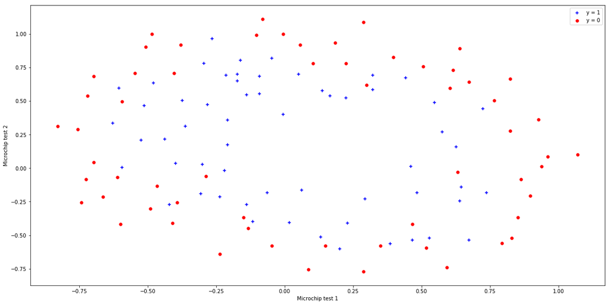

```python
ax = plotData(data2)
ax.legend(['y = 1', 'y = 0'], loc='best')
ax.set_xlabel('Microchip test 1')
ax.set_ylabel('Microchip test 2')
```

```python
def mapFeature(x1, x2):
    ret = np.array([x1**(i-j) * x2**j
                    for i in range(1,7) for j in range(i+1)
                   ])
    return np.insert(ret, 0, np.ones(len(x1)), 0).T

mapFeature(np.array([2,3]),np.array([3,2]))[:, :10]
```

```
array([[ 1,  2,  3,  4,  6,  9,  8, 12, 18, 27],
       [ 1,  3,  2,  9,  6,  4, 27, 18, 12,  8]])
```

Note that mapFeature also adds a column of ones for us, so the intercept term is handled.

```python
X = mapFeature(data2.test1, data2.test2)
y = data2.accepted.values
initial_theta = np.zeros(X.shape[1])
X.shape, y.shape, initial_theta.shape
```

```
((118, 28), (118,), (28,))
```

The cost at the initial theta is:

```python
cost(X, y, initial_theta)
```

```
0.69314718055994529
```

## Part 2: Regularization and Accuracies

Optional Exercise: In this part, you will get to try different values of lambda and see how regularization affects the decision coundart

Try the following values of lambda (0, 1, 10, 100).

How does the decision boundary change when you vary lambda? How does the training set accuracy vary?

```python
lambda_ = 0
```

```python
optimal_theta = scipy.optimize.fmin_bfgs(lambda t: cost(X, y, t, lambda_),
                                        initial_theta,
                                        lambda t: gradient(X, y, t, lambda_))
```

```
Optimization terminated successfully.
         Current function value: 0.224569
         Iterations: 546
         Function evaluations: 547
         Gradient evaluations: 547
```

At the optimal theta value, the accuracy is:

```python
print ('Regularized logistic regression, training accuracy : ' +str(np.mean(predict(optimal_theta, X) == y)))
```

```
Regularized logistic regression, training accuracy : 0.915254237288
```

```python
optimal_theta
```

```
array([   35.10190495,    44.11914868,    69.27187304,  -344.27900054,
        -198.23459425,  -184.22838035,  -295.82034848,  -621.7326665 ,
        -510.84929546,  -328.31181585,  1094.70017258,  1269.58577605,
        1757.74884292,   900.93777303,   436.58880204,   471.12024172,
        1236.238612  ,  1822.82026232,  1929.6675236 ,  1131.05309772,
         463.79926634, -1142.11722496, -2020.95906923, -3463.39955941,
       -3484.51043697, -3252.26729438, -1546.00925862,  -510.41266742])
```

The decision boundary:

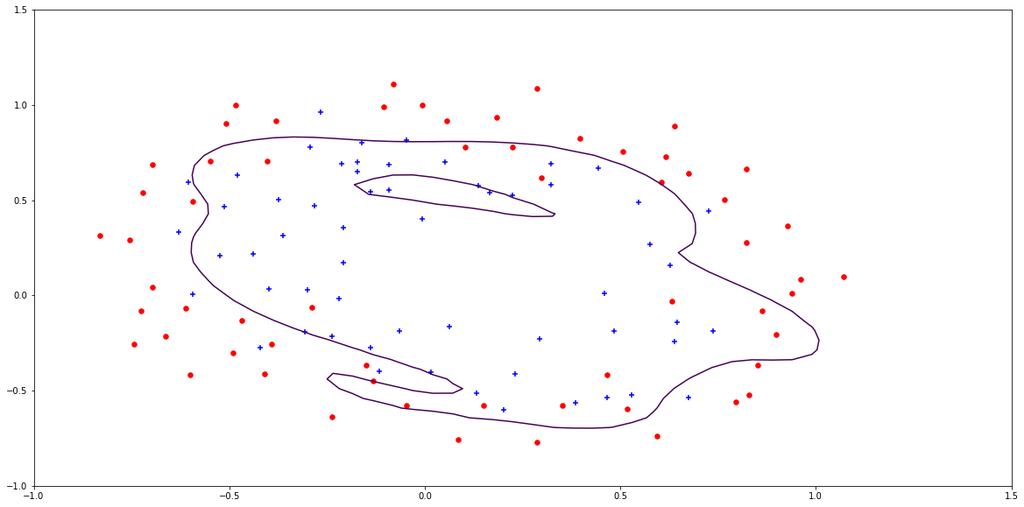

```python
contour_x = np.linspace(-1, 1.5)
contour_y = np.linspace(-1, 1.5)
def calc_z(x, y):
    return mapFeature(np.array([x]), np.array([y])).dot(optimal_theta)

z = np.zeros((len(contour_x), len(contour_y)))
for i, c_x in enumerate(contour_x):
    for j, c_y in enumerate(contour_y):
        z[i,j] = calc_z(c_x, c_y)[0]

ax = plotData(data2)
ax.contour(contour_x, contour_y, z, levels=[0])
```

```python
print (z)
```

```
[[ -16063.13011368  -13706.48596879  -11661.58793728 ...,   -1269.20435854
    -1484.58581575   -1738.22849796]
 [ -13565.95669178  -11489.45601424   -9697.0479795  ...,   -1056.98208965
    -1252.2454418    -1484.29650033]
 [ -11425.66935736   -9600.42961005   -8033.62043773 ...,    -882.73468913
    -1060.22373562   -1273.34198141]
 ...,
 [  -3233.96070564   -3005.29340977   -2813.8351956  ...,  -62599.68836033
   -70376.31014332  -79021.18761566]
 [  -4009.85216844   -3762.87353938   -3556.55700079 ...,  -71678.56828204
   -80252.83825004  -89758.62332537]
 [  -4952.61874097   -4687.4565687    -4466.78650809 ...,  -81909.99418018
   -91349.80695862 -101787.98257249]]
```

```python
contour_x = np.linspace(-1, 1.5)
```

```python
print (contour_x)
```

```
[-1.         -0.94897959 -0.89795918 -0.84693878 -0.79591837 -0.74489796
 -0.69387755 -0.64285714 -0.59183673 -0.54081633 -0.48979592 -0.43877551
 -0.3877551  -0.33673469 -0.28571429 -0.23469388 -0.18367347 -0.13265306
 -0.08163265 -0.03061224  0.02040816  0.07142857  0.12244898  0.17346939
  0.2244898   0.2755102   0.32653061  0.37755102  0.42857143  0.47959184
  0.53061224  0.58163265  0.63265306  0.68367347  0.73469388  0.78571429
  0.83673469  0.8877551   0.93877551  0.98979592  1.04081633  1.09183673
  1.14285714  1.19387755  1.24489796  1.29591837  1.34693878  1.39795918
  1.44897959  1.5       ]
```

```python
k=2
result_knn = predictKNN(X,y,k)
print ('K-nearest neighbors, k = '+str(k)+', training accuracy : ' + str(np.mean(result_knn == y)))
```

```
K-nearest neighbors, k = 2, training accuracy : 0.847457627119
```

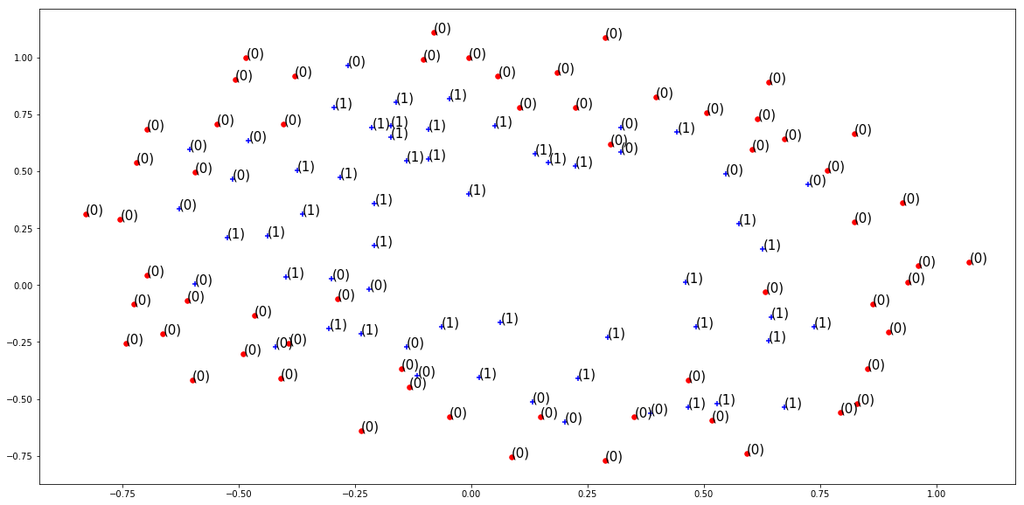

```python
ax = plotData(data2)
i = 0
for xy in zip(X[:,1],X[:,2]):
    ax.annotate('(%s)' % int(result_knn[i]), xy=xy, textcoords='data',size=15)
    i += 1
```

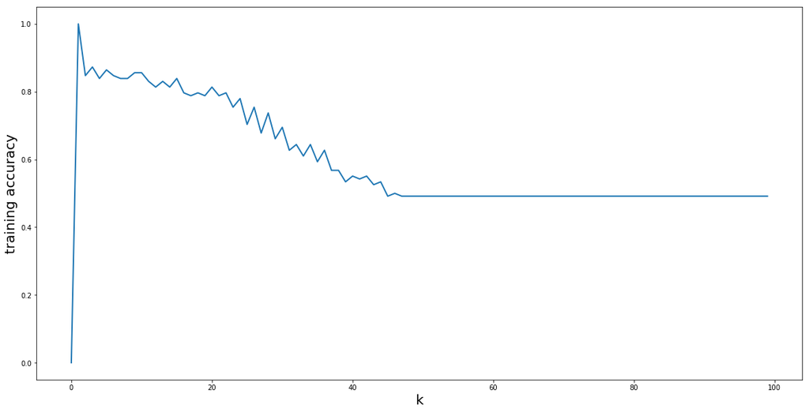

```python
accuracy_from_dif_k = np.zeros((100,))

for dif_k in range(1,100):
    result_knn = predictKNN(X,y,dif_k)
    accuracy = np.mean(result_knn == y)
    accuracy_from_dif_k[dif_k] = accuracy

plt.figure(figsize=(20,10))
plt.plot(accuracy_from_dif_k, linewidth=2.0)
plt.ylabel('training accuracy',fontsize=20)
plt.xlabel('k',fontsize=20)
plt.show()
```